# BarcelonaAccidents

# Introduction

Accidents are complex events, often influenced by a diverse range of factors such as location, time, weather conditions, and demographic attributes. The `AccidentAnalysis` package is designed to bridge the gap between raw data and insightful analysis. By seamlessly transforming intricate datasets into intuitive visual representations, this package empowers users to uncover significant patterns and trends. When a dataset is visualized using the package one can understand where the peak points are and concentrate on clearing them.

# Motivation

The package is aimed to find the causes and results of the accidents. By identifying these , one can understand the patterns to find the root cause and eliminate it to bring a better and safe society.

```r
library(Accidentanalysis)
```

# Dataset Used

The dataset used in the package is the Barcelona accidents dataset that is taken for the years 2017 to 2021. The dataset is chose because it is an easy example dataset that can be easiy explained and visualised.

## Loading the dataset

```r
#Load the dataset
 accidents <- load_accident_dataset()
```

### Displaying the first few records of the sample dataset

```r
# Display the first few rows of the dataset
 head(accidents)
```

```
#> # A tibble: 6 × 15
#>      Id `District Name` `Neighborhood Name`     Street Weekday Month   Day  Hour
#>   <dbl> <chr>           <chr>                   <chr>  <chr>   <chr> <dbl> <dbl>
#> 1   Inf Unknown         Unknown                 Númer… Friday  Octo…    13     8
#> 2   Inf Unknown         Unknown                 Númer… Friday  Sept…     1    13
#> 3   Inf Unknown         Unknown                 Litor… Friday  Dece…     8    21
#> 4   Inf Unknown         Unknown                 Númer… Friday  July     21     2
#> 5   Inf Sant Martí      el Camp de l'Arpa del … Las N… Thursd… May      25    14
#> 6   Inf Sant Martí      el Camp de l'Arpa del … Indús… Wednes… Sept…    20    12
#> # ℹ 7 more variables: `Part of the day` <chr>, `Mild injuries` <dbl>,
#> #   `Serious injuries` <dbl>, Victims <dbl>, `Vehicles involved` <dbl>,
#> #   Longitude <dbl>, Latitude <dbl>
```

```r
 # Summary statistics of the dataset
 summary(accidents)
```

```
#>        Id        District Name      Neighborhood Name     Street
#>  Min.   :20170   Length:10339       Length:10339       Length:10339
#>  1st Qu.:  Inf   Class :character   Class :character   Class :character
#>  Median :  Inf   Mode  :character   Mode  :character   Mode  :character
#>  Mean   :  Inf
#>  3rd Qu.:  Inf
#>  Max.   :  Inf
#>    Weekday             Month                Day             Hour
#>  Length:10339       Length:10339       Min.   : 1.00   Min.   : 0.00
#>  Class :character   Class :character   1st Qu.: 8.00   1st Qu.:10.00
#>  Mode  :character   Mode  :character   Median :16.00   Median :14.00
#>                                        Mean   :15.78   Mean   :13.81
#>                                        3rd Qu.:23.00   3rd Qu.:18.00
#>                                        Max.   :31.00   Max.   :23.00
#>  Part of the day    Mild injuries    Serious injuries     Victims
#>  Length:10339       Min.   : 0.000   Min.   :0.00000   Min.   : 0.000
#>  Class :character   1st Qu.: 1.000   1st Qu.:0.00000   1st Qu.: 1.000
#>  Mode  :character   Median : 1.000   Median :0.00000   Median : 1.000
#>                     Mean   : 1.154   Mean   :0.02331   Mean   : 1.179
#>                     3rd Qu.: 1.000   3rd Qu.:0.00000   3rd Qu.: 1.000
#>                     Max.   :10.000   Max.   :4.00000   Max.   :10.000
#>  Vehicles involved   Longitude        Latitude
#>  Min.   : 0.000    Min.   :2.092   Min.   :41.32
#>  1st Qu.: 2.000    1st Qu.:2.145   1st Qu.:41.39
#>  Median : 2.000    Median :2.163   Median :41.40
#>  Mean   : 1.921    Mean   :2.163   Mean   :41.40
#>  3rd Qu.: 2.000    3rd Qu.:2.180   3rd Qu.:41.41
#>  Max.   :14.000    Max.   :2.223   Max.   :41.47
```

## Severity Analysis

The concept of severity analysis takes into consideration the injuries of both types mild and severe and calculates the accidents that are highly occured in each of the district.

Perform a severity analysis and visualize the results using the `severity_analysis_plot` function:

```r
severity_analysis_plot <- function(data) {
  library(ggplot2)

  # Perform severity analysis (example calculation)
  severity_summary <- aggregate(
    cbind(Mild = `Mild injuries`, Serious = `Serious injuries`) ~ `District Name`,
    data = data,
    FUN = sum
  )

  # Plot severity analysis
  ggplot(severity_summary, aes(x = `District Name`, y = Mild + Serious, fill = `District Name`)) +
    geom_bar(stat = "identity") +
    labs(title = "Severity Analysis by District", x = "District Name", y = "Total Injuries") +
    theme_minimal() +
    theme(axis.text.x = element_text(angle = 45, hjust = 1)) +
    theme(plot.title = element_text(hjust = 0.5)) +
    theme(plot.margin = margin(10, 10, 20, 10, "pt")) +
    theme(legend.position = "none") +
    theme(panel.grid.major.x = element_blank()) +
    theme(panel.grid.minor.x = element_blank())
}
```

```r
library(dplyr)
```

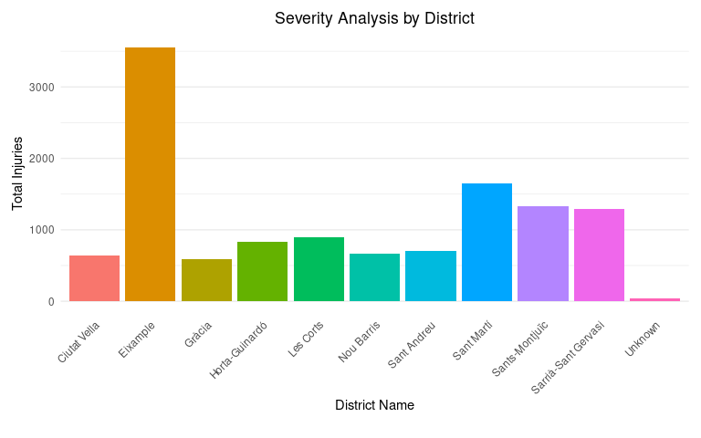

```r
severity_analysis_plot(accidents)
```

## Hourly Accident Distribution

These indicate the hour timings in which the accidents number raise to a peak. The traffic arrangements can be enhancement and route directions can be altered.

Visualize the distribution of accidents by hour of the day using the `plot_hourly_distribution` function:

```r
plot_hourly_distribution <- function(data) {
  library(ggplot2)

  ggplot(data, aes(x = Hour)) +
    geom_histogram(binwidth = 1, fill = "skyblue", color = "black") +
    labs(title = "Hourly Accident Distribution", x = "Hour of the Day", y = "Frequency") +
    theme_minimal()
}
```

```r
accidents <- load_accident_dataset()
```

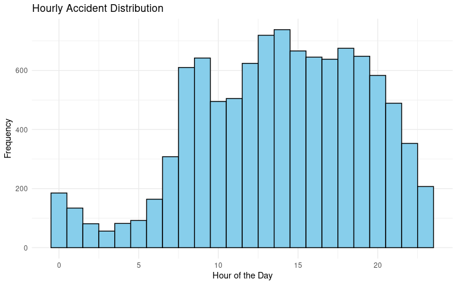

```r
plot_hourly_distribution(accidents)
```

## Vehicle Involvement Analysis

The number of vehicles restriction can be placed into account using this analysis. The control of flow of vehicles can use this to enhance their performance. Analyze the impact of the number of vehicles involved in accidents on severity using the `vehicle_involvement_analysis` function:

```r
vehicle_involvement_analysis <- function(data) {
  result <- data %>%
    group_by(`Vehicles involved`) %>%
    summarise(
      Avg_Mild = mean(`Mild injuries`),
      Avg_Serious = mean(`Serious injuries`),
      Total_Injuries = sum(`Mild injuries` + `Serious injuries`)
    )

  # Plot the results
  plot <- ggplot(result, aes(x = `Vehicles involved`, y = Total_Injuries, fill = `Vehicles involved`)) +
    geom_bar(stat = "identity") +
    labs(title = "Vehicle Involvement Analysis", x = "Number of Vehicles Involved", y = "Total Injuries") +
    theme_minimal()

  return(list(summary = result, plot = plot))
}
```

```r
library(magrittr)
library(dplyr)
vehicle_analysis_result <- vehicle_involvement_analysis(accidents)
vehicle_analysis_result$summary
```

```
#> # A tibble: 14 × 4
#>    `Vehicles involved` Avg_Mild Avg_Serious Total_Injuries
#>                  <dbl>    <dbl>       <dbl>          <dbl>
#>  1                   0    0          0                   0
#>  2                   1    0.959      0.0389           2255
#>  3                   2    1.17       0.0183           8381
#>  4                   3    1.41       0.0226           1143
#>  5                   4    1.58       0.0121            263
#>  6                   5    1.85       0.0417             91
#>  7                   6    1.64       0                  23
#>  8                   7    1.5        0                   9
#>  9                   8    1.5        0                   3
#> 10                   9    0.6        0                   3
#> 11                  10    0          0                   0
#> 12                  11    0          0                   0
#> 13                  13    1          2                   3
#> 14                  14    0          0                   0
```

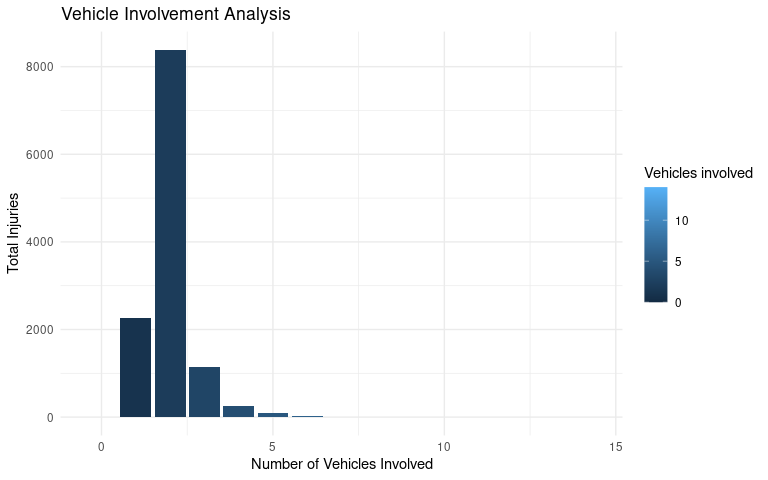

```r
print(vehicle_analysis_result$plot)
```

## Day of the Week Analysis

These help us identify the weekdays and weekends variations. The regulations and information to the society can help them be aware of the patterns and incidents. Analyze the distribution of accidents across different days of the week using the `day_of_week_analysis` function:

```r
day_of_week_analysis <- function(data) {
  result <- data %>%
    group_by(Weekday) %>%
    summarise(AccidentCount = n())

  # Plot the results using a scatter plot
  plot <- ggplot(result, aes(x = reorder(Weekday, -AccidentCount), y = AccidentCount, color = Weekday)) +
    geom_point(size = 4) +
    labs(title = "Day of the Week Analysis", x = "Day of the Week", y = "Accident Count") +
    theme_minimal() +
    theme(axis.text.x = element_text(angle = 45, hjust = 1))

  return(list(summary = result, plot = plot))
}
```

```r
#Statistical Analysis of the result
day_of_week_result <- day_of_week_analysis(accidents)
day_of_week_result$summary
```

```
#> # A tibble: 7 × 2
#>   Weekday   AccidentCount
#>   <chr>             <int>
#> 1 Friday             1761
#> 2 Monday             1510
#> 3 Saturday           1155
#> 4 Sunday              895
#> 5 Thursday           1677
#> 6 Tuesday            1691
#> 7 Wednesday          1650
```

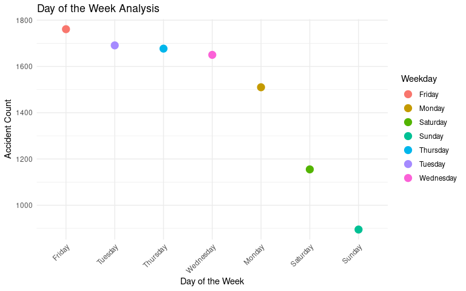

```r
#The plot that shows the accidents trend over the days of a week
print(day_of_week_result$plot)
```

## Warnings

There are a few warnings when run the check file. The first warning is related to the usage og packages, that is the way it is used. Instead of using library(package), the warning suggests to use package :: . The other one is the version specification. The clear idea of the version to use is not specified in the description file. The final warning is the latex, pdf generation warning.